# R Notebook

```r
library(tidyverse)
Sys.setenv(R_CONFIG_ACTIVE = Sys.info()["nodename"])
print(Sys.info()["nodename"])
```

```
                       nodename
"Benjamins-MacBook-Pro-3.local"
```

```r
dropbbox_dir <- config::get("dev_analysis_data_dir")
```

```r
time_points <- readr::read_csv(paste0(dropbbox_dir,"/SST_roi_by_time_point.csv"))
```

Now let’s see if we can graph putamen…

```r
library(ggplot2)
# ggplot(time_points,
#        aes(x=offset, y=`harvardoxford-subcortical_prob_Left Putamen`))+
#   geom_point()+
#   geom_smooth(method="loess",span=2,na.rm=TRUE) + #https://ggplot2.tidyverse.org/reference/geom_smooth.html
#   scale_y_continuous(limits=c(-2.5,2.5))+
#   facet_wrap(~condition)
```

we could also subtract the average per TRIAL. Best we subtract the average across all of the offsets. it’s a bit arbitrary to use the average over all the areas; the idea is just to get a consistent amount of average.

```r
roi_cols <- c("CueFollowing(CS>FS)striatal_cluster_combined")
time_points$tr_roi_mean <- rowMeans(time_points[,roi_cols])
time_points<-
  time_points %>% group_by(subid,wave) %>%
  mutate(run_mean_across_rois = mean(tr_roi_mean, na.rm = TRUE))

#now mean-center the ROIs
time_points_c<-time_points
#Removed this because it is irrelevant; these are already mean_centered when they come in. need to do a bit of work to see how that is.
# for (roi_col in roi_cols){
#   time_points_c[,roi_col]<-time_points_c[,roi_col]-time_points_c$run_mean_across_rois
# }
```

```r
sd(time_points$`harvardoxford-subcortical_prob_Left Putamen`)
```

```
[1] 0.4680374
```

```r
sd(time_points_c$`harvardoxford-subcortical_prob_Left Putamen`)
```

```
[1] 0.4680374
```

```r
library(ggplot2)
ggplot(time_points_c,
       aes(x=offset, y=`harvardoxford-subcortical_prob_Left Putamen`,group=interaction(trial_n,subid,wave)))+
  geom_line(alpha=0.2)+
  #geom_point()+
  #geom_smooth(method="loess",span=2,na.rm=TRUE) + #https://ggplot2.tidyverse.org/reference/geom_smooth.html
  scale_y_continuous(limits=c(-2.5,2.5))+
  facet_wrap(~condition)
```

```
Error in FUN(X[[i]], ...) :
  object 'harvardoxford-subcortical_prob_Left Putamen' not found
```

Now let’s try just graphing the moving average…

```r
library(tidyverse)

#get the range of offsets
min_offset<-round(min(time_points_c$offset))
max_offset <- round(max(time_points_c$offset))

seq_size <- 0.1
offset_size<-1
offset_times <- seq(min_offset,max_offset-max(offset_size,seq_size),seq_size)

dt_list<-list()
for (cond in unique(time_points_c$condition)){
  print(cond)
  for (ot_i in offset_times){
  #<-offset_times[[20]]

  tp_at_offset <- time_points_c %>% filter(offset>=ot_i & offset<(ot_i+offset_size) & condition==cond)
  numeric_cols <- colnames(tp_at_offset)[sapply(tp_at_offset,class)=="numeric"]
  tp_at_offset_m <- data.frame(t(colMeans(tp_at_offset[,numeric_cols],na.rm=TRUE)))
  tp_at_offset_m$offset_start<-ot_i
  tp_at_offset_m$condition<-cond
  dt_list<-append(dt_list,list(tp_at_offset_m))
  if((which(ot_i==offset_times)%%20)==0){
    cat(". ")
  }


  }
  print("")

}
```

```
[1] "FailedStop"
```

# get the delay to next trial

```r
behavioral_data_w_tone_data <- readr::read_csv(paste0(dropbbox_dir,"/sst_behavioral_data_all_w_class_type_reveal_onset.csv"))
# I want to know: what is the time delay from the tone sound to the PERIOD of the next trial?
```

```r
#so I want to match each trial up with the _next_ trial
#grab the set of next trials-we want their onset and their duration
#then match that back onto n+1 of their prior trial
trial_df <- behavioral_data_w_tone_data %>% filter(condition!="Cue") %>%
  arrange(trial_n) %>%
  group_by(subid,waveid,runid) %>%
  mutate(next_trial_n = lead(trial_n,1)) %>%
  ungroup()


next_trial_df <- behavioral_data_w_tone_data %>%
  filter(condition!="Cue") %>%
  select(trial_n,condition,onset,trial_duration,subid,waveid,runid)


trials_with_next<-merge(
  trial_df,next_trial_df,
  by.x = c("subid","waveid","runid", "next_trial_n"),
  by.y=c("subid","waveid","runid","trial_n"),
  suffixes = c("","_next"))
```

now, mark for each trial the start and end time point of the next trial, and get measures of how long after each trial the next one appears

```r
trials_with_next$trial_end_next <- trials_with_next$onset_next+trials_with_next$trial_duration_next
trials_with_next$class_type_reveal_onset_to_next_trial_start<-trials_with_next$onset_next-trials_with_next$class_type_reveal_onset
trials_with_next$class_type_reveal_onset_to_next_trial_end<-trials_with_next$trial_end_next-trials_with_next$class_type_reveal_onset
```

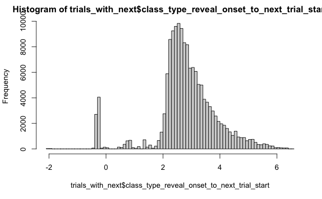

```r
hist(trials_with_next$class_type_reveal_onset_to_next_trial_start,breaks = 100)
```

```r
median(trials_with_next$class_type_reveal_onset_to_next_trial_start)
```

```
[1] 2.777436
```

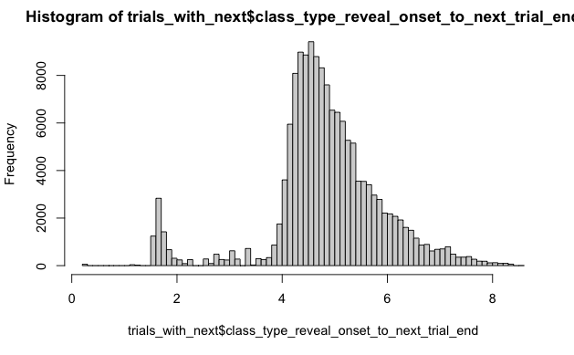

```r
hist(trials_with_next$class_type_reveal_onset_to_next_trial_end,breaks = 100)
```

```r
median(trials_with_next$class_type_reveal_onset_to_next_trial_end)
```

```
[1] 4.782311
```

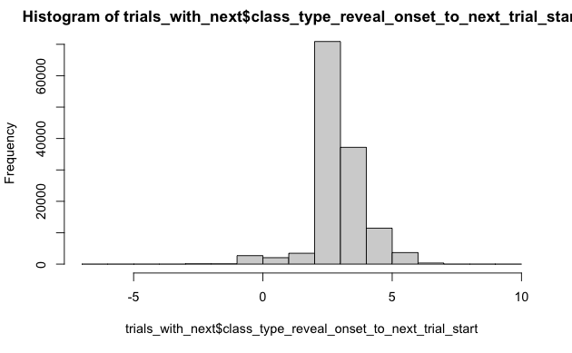

```r
hist(trials_with_next$class_type_reveal_onset_to_next_trial_start)
```

```r
next_trial_median <- data.frame(
  "next_trial_start_median" = median(trials_with_next$class_type_reveal_onset_to_next_trial_start),
  "next_trial_end_median" = median(trials_with_next$class_type_reveal_onset_to_next_trial_end)
  )

quantiles <- (1:10)/10
# next_trial_gradient <- data.frame(
#   "quantiles" = quantiles,
#   "next_trial_start" = quantile(trials_with_next$class_type_reveal_onset_to_next_trial_start,(1:10)/10),
#   "next_trial_end" = quantile(trials_with_next$class_type_reveal_onset_to_next_trial_end,(1:10)/10)
#   )

gradient_range = seq(floor(min(trials_with_next$class_type_reveal_onset_to_next_trial_start)),ceiling(max(trials_with_next$class_type_reveal_onset_to_next_trial_end)),0.1)

in_range_by_gradient <- sapply(gradient_range,function(tp){
  time_point_is_after_start <- tp > trials_with_next$class_type_reveal_onset_to_next_trial_start
  time_point_is_before_end <- tp < trials_with_next$class_type_reveal_onset_to_next_trial_end
  number_of_trials <- length(trials_with_next$class_type_reveal_onset_to_next_trial_start)
  return(sum(time_point_is_after_start & time_point_is_before_end)/number_of_trials)
})

next_trial_gradient <- data.frame("tp"=gradient_range,"pct_in_range"=in_range_by_gradient)
```

# do graphs

```r
subj_count <- length(unique(time_points_c$subid))
#df_offset_long<-df_offset# %>% pivot_longer(cols=roi_cols,names_to="ROI_fullname",values_to="value")
# df_offset_long$ROI<-stringr::str_extract_all(df_offset_long$ROI_fullname,pattern = "(?<=harvardoxford\\..{0,3}cortical_prob_)(.*)") %>% sub("\\."," ",.)

# unique_rois<-sort(unique(df_offset_long$ROI))
# unique_rois_ordered <- unique_rois[order(unique_rois %>% str_extract("(?<=.{3,5}\\s)(.*)"))]

# df_offset_long$ROI<-factor(df_offset_long$ROI,levels = unique_rois_ordered, ordered=TRUE)

ggplot_time_points_extras <- list(
  geom_vline(xintercept = 0,linetype="dashed"),
  geom_hline(yintercept = 0,linetype="dotted"),
  labs(
    x="time from tone sound or expected time of tone (s)",
    y="mean BOLD activity (no HRF convolution)",
    #title="Stop Signal Task Activity",
    subtitle=paste0("Across ", as.character(subj_count)," subjects with 128 trials each"),
    caption="0 point is the moment of tone sound (Stop trials)\n or expected tone sound based on prior trial (Go trials)\n HRF convolution not applied\n1 s moving averages")
  )

df_offset
```

| ...1 | tr | offset | CueFollowing.CS.FS.striatal_cluster_combined_20230512 | CueFollowing.CS.FS.striatal_cluster_combined_20221207 | CueFollowing.CS.FS.striatal_cluster_combined | Frontal.Orbital.Cortex | Cingulate.Gyrus..anterior.division | Left.Caudate | Right.Accumbens | Right.Putamen | Left.Putamen | Right.Caudate | Left.Accumbens | t_class_type_reveal_onset | wave | trial_n | tr_roi_mean | run_mean_across_rois | offset_start | condition |
| --- | --- | --- | --- | --- | --- | --- | --- | --- | --- | --- | --- | --- | --- | --- | --- | --- | --- | --- | --- | --- |
| 876.7458 | 185.6470 | -9.4866148409 | 2.671029e-03 | 1.076596e-03 | 2.671029e-03 | -3.868149e-02 | -2.420535e-02 | -1.591114e-02 | 1.969235e-03 | -3.092505e-03 | -1.115148e-03 | -2.233452e-02 | 4.551691e-03 | 195.1336 | 1.501133 | 118.6239 | -1.110994e-02 | 0.001242466 | -10.0 | FailedStop |
| 885.3224 | 187.5950 | -9.4055626649 | -1.811689e-03 | -3.150236e-03 | -1.811689e-03 | -4.152340e-02 | -2.618260e-02 | -2.383896e-02 | 2.605865e-03 | -6.517176e-03 | -4.039532e-03 | -2.937551e-02 | 4.743273e-04 | 197.0006 | 1.500000 | 119.7560 | -1.482850e-02 | 0.001221124 | -9.9 | FailedStop |
| 892.1198 | 189.0820 | -9.3224833576 | 5.427955e-03 | 4.894470e-03 | 5.427955e-03 | -3.933242e-02 | -2.279213e-02 | -2.077722e-02 | 1.663301e-02 | -2.058059e-04 | -1.543777e-03 | -2.499893e-02 | 4.193925e-03 | 198.4045 | 1.482320 | 120.6558 | -9.816569e-03 | 0.001286349 | -9.8 | FailedStop |
| 881.8552 | 186.8873 | -9.2143348192 | 9.436848e-03 | 9.198450e-03 | 9.436848e-03 | -3.732795e-02 | -1.893779e-02 | -1.751470e-02 | 1.404261e-02 | 5.331995e-03 | 2.166596e-03 | -1.899753e-02 | 1.260414e-03 | 196.1017 | 1.453736 | 119.2806 | -7.394675e-03 | 0.001352369 | -9.7 | FailedStop |
| 879.4396 | 186.5450 | -9.1197131382 | 5.019031e-03 | 5.329381e-03 | 5.019031e-03 | -3.725690e-02 | -1.546810e-02 | -2.104074e-02 | 8.290997e-03 | 3.468652e-04 | -2.084527e-03 | -1.731046e-02 | 8.924157e-04 | 195.6647 | 1.433704 | 118.9645 | -9.052880e-03 | 0.001400926 | -9.6 | FailedStop |
| 885.7155 | 188.0943 | -9.0127506915 | 3.180116e-03 | 3.611159e-03 | 3.180116e-03 | -3.196124e-02 | -1.128538e-02 | -1.980444e-02 | 5.851080e-03 | 1.794641e-03 | -1.190246e-03 | -1.577875e-02 | 2.967291e-03 | 197.1070 | 1.414762 | 119.8067 | -7.205030e-03 | 0.001470850 | -9.5 | FailedStop |
| 886.1294 | 188.3900 | -8.8943489287 | 3.217041e-03 | 4.360690e-03 | 3.217041e-03 | -2.455674e-02 | -5.097541e-03 | -1.812912e-02 | 6.371603e-03 | 2.778190e-03 | 3.470492e-03 | -1.445262e-02 | 1.718519e-03 | 197.2844 | 1.408454 | 119.8627 | -4.581200e-03 | 0.001405952 | -9.4 | FailedStop |
| 905.5577 | 192.9181 | -8.8012255283 | -1.567010e-03 | 2.972872e-04 | -1.567010e-03 | -1.901566e-02 | -3.082655e-03 | -1.929722e-02 | 4.538368e-03 | 3.040480e-03 | -2.565205e-03 | -1.274967e-02 | 7.093023e-04 | 201.7193 | 1.406085 | 122.4586 | -4.697879e-03 | 0.001354902 | -9.3 | FailedStop |
| 908.5186 | 193.6946 | -8.6886857396 | -8.628600e-03 | -7.961634e-03 | -8.628600e-03 | -1.705486e-02 | -4.528758e-03 | -2.426411e-02 | -1.670373e-03 | 8.972773e-04 | -2.302991e-03 | -1.917034e-02 | -9.922391e-03 | 202.3833 | 1.406242 | 122.8612 | -8.285987e-03 | 0.001466082 | -9.2 | FailedStop |
| 948.9545 | 202.7157 | -8.5760873748 | -1.772363e-02 | -1.668432e-02 | -1.772363e-02 | -2.145084e-02 | -1.075273e-02 | -3.044034e-02 | -8.602034e-03 | -4.446823e-03 | -6.503946e-03 | -2.656803e-02 | -1.753432e-02 | 211.2918 | 1.427708 | 128.2616 | -1.438783e-02 | 0.001399550 | -9.1 | FailedStop |

[output cut: 990 more lines]

```r
plot_final<-ggplot(df_offset,
       aes(x=offset_start, y=CueFollowing.CS.FS.striatal_cluster_combined,color=condition))+
  geom_line()+
  #facet_wrap(~ROI,ncol = 2)+
  ggplot_time_points_extras

  #geom_point()+
  #geom_smooth(method="loess",span=2,na.rm=TRUE) + #https://ggplot2.tidyverse.org/reference/geom_smooth.html
  #scale_y_continuous(limits=c(-2.5,2.5))
```

```r
ggsave(plot_final,filename="compare_conditions.pdf",device="pdf",width = 2, height=1,scale=4)
```

It’s almost as if there’s an “update” signal at t=2, then a “RPE” signal at t=5-10.

## Just stop trials, divided separately

[figure not shown]

## CS-FS

Let’s now try to contrast these time series to see what the CS-FS looks like. This will be interesting because it’s similar to the simple GLM result I got earlier that set me down the path of trying to analyze this.

```r
trial_tps_compare_conditions<-df_offset %>% pivot_wider(id_cols=c(offset_start),names_from = "condition",values_from="CueFollowing.CS.FS.striatal_cluster_combined")
trial_tps_compare_conditions$CS_minus_FS<-trial_tps_compare_conditions$CorrectStop-trial_tps_compare_conditions$FailedStop
```

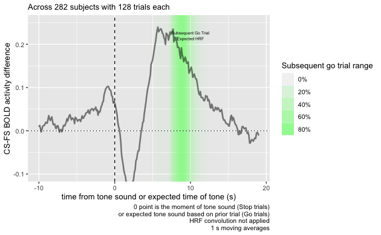

```r
ggplot(trial_tps_compare_conditions,
       aes(x=offset_start, y=CS_minus_FS))+
  #geom_tile(data = next_trial_gradient, aes(x=tp,alpha=pct_in_range,y=0),fill="#000000",color="transparent")+
  geom_tile(data = next_trial_gradient, aes(x=hrf_tp,alpha=pct_in_range,y=0),fill="#77ff77",color="transparent")+
  #annotate("text",x=4,y=0.25,label="Subsequent Go Trial\nTime Range",size=2)+
  annotate("text",x=10,y=0.22,label="Subsequent Go Trial\nExpected HRF",size=2)+
  scale_alpha_continuous(name="Subsequent go trial range", range=c(0,0.7),labels=scales::percent_format())+
  geom_line(size=1,alpha=0.5)+
  scale_color_viridis_d(option = "C")+
  ggplot_time_points_extras+
  coord_cartesian(ylim=c(-0.1,0.25))+
  labs(y="CS-FS BOLD activity difference")
```

```r
NA
```

OK, so from this graph it is very clear why, during the subsequent trial, we’re seeing positive striatum activity, and it is also clear there is a large dip in the same area right after the tone.

## find a way to compare activity from the start and end. Is there a sort of habituation effect?

Easy way first. Take just CS or FS, then do one graph per ROI, use color with the order of the task.

```r
roi_cols <- colnames(time_points_c)[grepl("harvardoxford",colnames(time_points))]

next_trial_gradient$hrf_tp<-next_trial_gradient$tp+5

time_points_long<-time_points_c %>% pivot_longer(cols=roi_cols,names_to="ROI",values_to="value")

unique_rois<-sort(unique(time_points_long$ROI))
unique_rois_ordered <- unique_rois[order(unique_rois %>% str_extract("(?<=.{3,5}\\.)([A-Za-z]*)$"))]

time_points_long$ROI<-factor(time_points_long$ROI,levels = unique_rois_ordered, ordered=TRUE)


for (c_i in unique(time_points_long$condition)){
  c_plot <- ggplot(time_points_long %>% filter(condition==c_i),
       aes(x=offset, y=value,color=trial_n))+
  facet_wrap(~ROI)+
  geom_tile(data = next_trial_gradient, aes(x=hrf_tp,alpha=pct_in_range,y=0),fill="#77ff77",color="transparent")+
  annotate("text",x=10,y=0.22,label="Subsequent Go Trial\nExpected HRF",size=2)+
  geom_line(size=1,alpha=0.1)+
  #scale_color_viridis_d(option = "C")+
  #coord_cartesian(ylim=c(-0.1,0.25))+
  ggplot_time_points_extras
  print(c_plot)

}
```

[output not shown]

# Re-scale the models

```r
load("modeling_t_5_10-activity.RData")
```

```
cannot open compressed file 'modeling_t_5_10-activity.RData', probable reason 'No such file or directory'Error in readChar(con, 5L, useBytes = TRUE) : cannot open the connection
```

However, we might want to re-do the model using z-values for P_stop_trial_change and post_pre_rt_change in order to get more realistic values.

```r
summary(model_full_effects_incc_abs)
```

```
Error in summary(model_full_effects_incc_abs) :
  object 'model_full_effects_incc_abs' not found
```

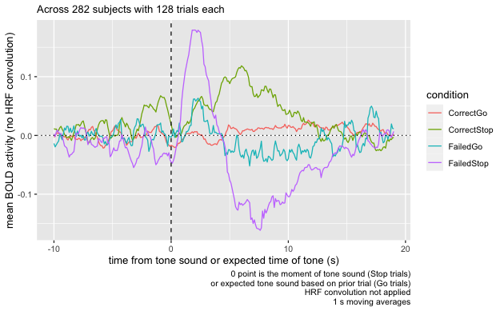

```r
subj_count <- length(unique(time_points_c$subid))
ggplot(df_offset,
       aes(x=offset_start, y=CueFollowing.CS.FS.striatal_cluster_combined,color=condition))+
  geom_line()+
  #facet_wrap(~ROI,ncol = 2)+
  ggplot_time_points_extras
```

```r
  model_full_effects_incc_abs
```

```
Error: object 'model_full_effects_incc_abs' not found
```

```r
model_full_effects_incc <- lme4::lmer(
   med_post_trial_z ~ trial_n_s+ condition + P_stop_trial_change+ post_pre_rt_change + (1 +post_pre_rt_change  + P_stop_trial_change  | subid),
  trial_neural_behav_roi %>% filter(trial_n>50 & condition %in% c("CorrectStop","FailedStop"))
  )
```

```
Error: bad 'data': object 'trial_neural_behav_roi' not found
```

```r
model_full_effects_abs <- lme4::lmer(
   med_post_trial ~ trial_n_s+ condition + P_stop_trial_change+ post_pre_rt_change + (1 +post_pre_rt_change  + P_stop_trial_change  | subid),
  trial_neural_behav_roi %>% filter(trial_n>50 & condition %in% c("CorrectStop","FailedStop"))
  )
summary(model_full_effects_abs)
```

```r
model_full_effects_x_zs <- lme4::lmer(
   med_post_trial ~ trial_n_z+ condition + P_stop_trial_change_z+ post_pre_rt_change_z + (1 +post_pre_rt_change_z  + P_stop_trial_change_z  | subid),
  trial_neural_behav_roi %>% filter(trial_n>50 & condition %in% c("CorrectStop","FailedStop"))
  )
summary(model_full_effects_x_zs)
```

```r
trial_neural_behav_roi_stop<-trial_neural_behav_roi %>% filter(trial_n>50 & condition %in% c("CorrectStop","FailedStop"))

plot(trial_neural_behav_roi_stop$P_stop_trial_change_z,trial_neural_behav_roi_stop$med_post_trial)

plot(trial_neural_behav_roi_stop$post_pre_rt_change_z,trial_neural_behav_roi_stop$med_post_trial)
```

```r
ggplot(trial_neural_behav_roi_stop,aes(post_pre_rt_change_z, med_post_trial_z))
plot(trial_neural_behav_roi_stop$post_pre_rt_change_z,trial_neural_behav_roi_stop$med_post_trial_z)
```

```r
trial_neural_behav_roi_stop<- trial_neural_behav_roi_stop %>%
  mutate(P_stop_trial_change_z_stop = (P_stop_trial_change-mean(P_stop_trial_change))/sd(P_stop_trial_change),
         post_pre_rt_change_z_stop = (post_pre_rt_change_z-mean(post_pre_rt_change_z))/sd(post_pre_rt_change_z)
         )

plot(trial_neural_behav_roi_stop$P_stop_trial_change_z_stop,trial_neural_behav_roi_stop$med_post_trial)
plot(trial_neural_behav_roi_stop$post_pre_rt_change_z_stop,trial_neural_behav_roi_stop$med_post_trial)
```

Alright–now what do we get?

```r
model_full_effects_x_zs <- lme4::lmer(
   med_post_trial ~ trial_n_z+ condition + P_stop_trial_change_z_stop+ post_pre_rt_change_z_stop + (1 +P_stop_trial_change_z_stop  + post_pre_rt_change_z_stop  | subid),
  trial_neural_behav_roi_stop)
summary(model_full_effects_x_zs)
```

[output not shown]

# Draw estimates on graph

```r
#the estimates apply to the median value at the x-range 4 to 10, so use that.
#also label them by condition
#let's add them to the table as additional lines
df_betas_wide <- data.frame(
  "offset_start_begin"=4,
  "offset_start_end"=10,
  "beta_name"="test_beta",
  "condition"="CorrectStop",
  "CueFollowing.CS.FS.striatal_cluster_combined"=0.1,
  ind=(nrow(df_offset)+1):(nrow(df_offset)+1)
)

df_betas <- df_betas_wide %>% tidyr::pivot_longer(cols=c("offset_start_begin","offset_start_end"),
                                                  names_to="point_type",values_to="offset_start")


df_draw <- merge(
  df_offset %>% mutate("dtype"="bold"),
  df_betas %>% mutate("dtype"="beta estimate"),
  by=c(intersect(colnames(df_offset),colnames(df_betas)),"dtype"),all=TRUE
)


ggplot(df_draw,
       aes(x=offset_start, y=CueFollowing.CS.FS.striatal_cluster_combined,
           color=condition,
           linetype=dtype,
           group=interaction(condition,dtype)))+
  geom_line()+
  #facet_wrap(~ROI,ncol = 2)+
  ggplot_time_points_extras
```

[output not shown]

Maybe arrows pointing to +-1 SD??